# Kalman Filter Implementation for Constant Acceleration Model (CA) in Python

Multisensor Data Fusion with acceleration ($\ddot x$ and $\ddot y$) and position ($x$ and $y$).

`CC-BY-SA2.0 Lizenz Paul Balzer, Motorblog http://www.cbcity.de`

[figure not shown]

First, we have to initialize the matrices and vectors. Setting up the math.

## State Vector

Constant Acceleration Model for Ego Motion in Plane

$$x_k= \left[ \begin{matrix} x \\ y \\ \dot x \\ \dot y \\ \ddot x \\ \ddot y \end{matrix} \right]$$

## Motion

Formal Definition:

$$x_{k+1} = A \cdot x_{k} + B \cdot u$$

Hence, we have no control input $u$:

$$x_{k+1} = \begin{bmatrix}1 & 0 & \Delta t & 0 & \frac{1}{2}\Delta t^2 & 0 \\ 0 & 1 & 0 & \Delta t & 0 & \frac{1}{2}\Delta t^2 \\ 0 & 0 & 1 & 0 & \Delta t & 0 \\ 0 & 0 & 0 & 1 & 0 & \Delta t \\ 0 & 0 & 0 & 0 & 1 & 0 \\ 0 & 0 & 0 & 0 & 0 & 1\end{bmatrix} \cdot \begin{bmatrix} x \\ y \\ \dot x \\ \dot y \\ \ddot x \\ \ddot y\end{bmatrix}_{k}$$

### Measurement

$$y = H \cdot x$$

Acceleration ($\ddot x$ & $\ddot y$) as well as position ($x$ & $y$) is measured.

$$y = \begin{bmatrix}1 & 0 & 0 & 0 & 0 & 0 \\0 & 1 & 0 & 0 & 0 & 0 \\ 0 & 0 & 0 & 0 & 1 & 0 \\ 0 & 0 & 0 & 0 & 0 & 1\end{bmatrix} \cdot x$$

## Setting up the math

#### Initial State

```python
x = np.matrix([[0.0, 0.0, 10.0, 0.0, 0.0, 0.0]]).T
print(x, x.shape)
n=x.size # States
#plt.scatter(float(x[0]),float(x[1]), s=100)
#plt.title('Initial Location')
```

```
(matrix([[  0.],
        [  0.],
        [ 10.],
        [  0.],
        [  0.],
        [  0.]]), (6, 1))
```

#### Initial Uncertainty

```python
P = np.diag([100.0, 100.0, 10.0, 10.0, 1.0, 1.0])
print(P, P.shape)
```

```
(array([[ 100.,    0.,    0.,    0.,    0.,    0.],
       [   0.,  100.,    0.,    0.,    0.,    0.],
       [   0.,    0.,   10.,    0.,    0.,    0.],
       [   0.,    0.,    0.,   10.,    0.,    0.],
       [   0.,    0.,    0.,    0.,    1.,    0.],
       [   0.,    0.,    0.,    0.,    0.,    1.]]), (6, 6))
```

## Dynamic Matrix

It is calculated from the dynamics of the Egomotion.

$$x_{k+1} = x_{k} + \dot x_{k} \cdot \Delta t + \ddot x_k \cdot \frac{1}{2}\Delta t^2$$$$y_{k+1} = y_{k} + \dot y_{k} \cdot \Delta t + \ddot y_k \cdot \frac{1}{2}\Delta t^2$$$$\dot x_{k+1} = \dot x_{k} + \ddot x \cdot \Delta t$$$$\dot y_{k+1} = \dot y_{k} + \ddot y \cdot \Delta t$$$$\ddot x_{k+1} = \ddot x_{k}$$$$\ddot y_{k+1} = \ddot y_{k}$$

```python
dt = 0.1 # Time Step between Filter Steps

A = np.matrix([[1.0, 0.0, dt, 0.0, 1/2.0*dt**2, 0.0],
              [0.0, 1.0, 0.0, dt, 0.0, 1/2.0*dt**2],
              [0.0, 0.0, 1.0, 0.0, dt, 0.0],
              [0.0, 0.0, 0.0, 1.0, 0.0, dt],
              [0.0, 0.0, 0.0, 0.0, 1.0, 0.0],
              [0.0, 0.0, 0.0, 0.0, 0.0, 1.0]])
print(A, A.shape)
```

```
(matrix([[ 1.   ,  0.   ,  0.1  ,  0.   ,  0.005,  0.   ],
        [ 0.   ,  1.   ,  0.   ,  0.1  ,  0.   ,  0.005],
        [ 0.   ,  0.   ,  1.   ,  0.   ,  0.1  ,  0.   ],
        [ 0.   ,  0.   ,  0.   ,  1.   ,  0.   ,  0.1  ],
        [ 0.   ,  0.   ,  0.   ,  0.   ,  1.   ,  0.   ],
        [ 0.   ,  0.   ,  0.   ,  0.   ,  0.   ,  1.   ]]), (6, 6))
```

## Measurement Matrix $H$

Here you can determine, which of the states is covered by a measurement. In this example, the position ($x$ and $y$) as well as the acceleration is measured ($\ddot x$ and $\ddot y$).

```python
H = np.matrix([[1.0, 0.0, 0.0, 0.0, 0.0, 0.0],
               [0.0, 1.0, 0.0, 0.0, 0.0, 0.0],
               [0.0, 0.0, 0.0, 0.0, 1.0, 0.0],
              [0.0, 0.0, 0.0, 0.0, 0.0, 1.0]])
print(H, H.shape)
```

```
(matrix([[ 1.,  0.,  0.,  0.,  0.,  0.],
        [ 0.,  1.,  0.,  0.,  0.,  0.],
        [ 0.,  0.,  0.,  0.,  1.,  0.],
        [ 0.,  0.,  0.,  0.,  0.,  1.]]), (4, 6))
```

## Measurement Noise Covariance $R$

```python
ra = 10.0**2   # Noise of Acceleration Measurement
rp = 100.0**2  # Noise of Position Measurement
R = np.matrix([[rp, 0.0, 0.0, 0.0],
               [0.0, rp, 0.0, 0.0],
               [0.0, 0.0, ra, 0.0],
               [0.0, 0.0, 0.0, ra]])
print(R, R.shape)
```

```
(matrix([[ 10000.,      0.,      0.,      0.],
        [     0.,  10000.,      0.,      0.],
        [     0.,      0.,    100.,      0.],
        [     0.,      0.,      0.,    100.]]), (4, 4))
```

## Process Noise Covariance Matrix $Q$

The Position of an object can be influenced by a force (e.g. wind), which leads to an acceleration disturbance (noise). This process noise has to be modeled with the process noise covariance matrix Q.

$$Q = \begin{bmatrix}\sigma_{x}^2 & \sigma_{xy} & \sigma_{x \dot x} & \sigma_{x \dot y} & \sigma_{x \ddot x} & \sigma_{x \ddot y} \\ \sigma_{yx} & \sigma_{y}^2 & \sigma_{y \dot x} & \sigma_{y \dot y} & \sigma_{y \ddot x} & \sigma_{y \ddot y} \\ \sigma_{\dot x x} & \sigma_{\dot x y} & \sigma_{\dot x}^2 & \sigma_{\dot x \dot y} & \sigma_{\dot x \ddot x} & \sigma_{\dot x \ddot y} \\ \sigma_{\dot y x} & \sigma_{\dot y y} & \sigma_{\dot y \dot x} & \sigma_{\dot y}^2 & \sigma_{\dot y \ddot x} & \sigma_{\dot y \ddot y} \\ \sigma_{\ddot x x} & \sigma_{\ddot x y} & \sigma_{\ddot x \dot x} & \sigma_{\ddot x \dot y} & \sigma_{\ddot x}^2 & \sigma_{\ddot x \ddot y} \\ \sigma_{\ddot y x} & \sigma_{\ddot y y} & \sigma_{\ddot y \dot x} & \sigma_{\ddot y \dot y} & \sigma_{\ddot y \ddot x} & \sigma_{\ddot y}^2\end{bmatrix}$$

To easily calcualte Q, one can ask the question: How the noise effects my state vector? For example, how the acceleration change the position over one timestep dt.

One can calculate Q as

$$Q = G\cdot G^T \cdot \sigma_a^2$$

with $G = \begin{bmatrix}0.5dt^2 & 0.5dt^2 & dt & dt & 1.0 & 1.0\end{bmatrix}^T$ and $\sigma_a$ as the acceleration process noise.

```python
from sympy import Symbol, Matrix
from sympy.interactive import printing
printing.init_printing()
dts = Symbol('\Delta t')
Qs = Matrix([[0.5*dts**2],[0.5*dts**2],[dts],[dts],[1.0],[1.0]])
Qs*Qs.T
```

$$\left[\begin{matrix}0.25 \Delta t^{4} & 0.25 \Delta t^{4} & 0.5 \Delta t^{3} & 0.5 \Delta t^{3} & 0.5 \Delta t^{2} & 0.5 \Delta t^{2}\\0.25 \Delta t^{4} & 0.25 \Delta t^{4} & 0.5 \Delta t^{3} & 0.5 \Delta t^{3} & 0.5 \Delta t^{2} & 0.5 \Delta t^{2}\\0.5 \Delta t^{3} & 0.5 \Delta t^{3} & \Delta t^{2} & \Delta t^{2} & 1.0 \Delta t & 1.0 \Delta t\\0.5 \Delta t^{3} & 0.5 \Delta t^{3} & \Delta t^{2} & \Delta t^{2} & 1.0 \Delta t & 1.0 \Delta t\\0.5 \Delta t^{2} & 0.5 \Delta t^{2} & 1.0 \Delta t & 1.0 \Delta t & 1.0 & 1.0\\0.5 \Delta t^{2} & 0.5 \Delta t^{2} & 1.0 \Delta t & 1.0 \Delta t & 1.0 & 1.0\end{matrix}\right]$$

```python
sa = 0.001
G = np.matrix([[1/2.0*dt**2],
               [1/2.0*dt**2],
               [dt],
               [dt],
               [1.0],
               [1.0]])
Q = G*G.T*sa**2

print(Q, Q.shape)
```

```
(matrix([[  2.50000000e-11,   2.50000000e-11,   5.00000000e-10,
           5.00000000e-10,   5.00000000e-09,   5.00000000e-09],
        [  2.50000000e-11,   2.50000000e-11,   5.00000000e-10,
           5.00000000e-10,   5.00000000e-09,   5.00000000e-09],
        [  5.00000000e-10,   5.00000000e-10,   1.00000000e-08,
           1.00000000e-08,   1.00000000e-07,   1.00000000e-07],
        [  5.00000000e-10,   5.00000000e-10,   1.00000000e-08,
           1.00000000e-08,   1.00000000e-07,   1.00000000e-07],
        [  5.00000000e-09,   5.00000000e-09,   1.00000000e-07,
           1.00000000e-07,   1.00000000e-06,   1.00000000e-06],
        [  5.00000000e-09,   5.00000000e-09,   1.00000000e-07,
           1.00000000e-07,   1.00000000e-06,   1.00000000e-06]]), (6, 6))
```

## Identity Matrix $I$

```python
I = np.eye(n)
print(I, I.shape)
```

```
(array([[ 1.,  0.,  0.,  0.,  0.,  0.],
       [ 0.,  1.,  0.,  0.,  0.,  0.],
       [ 0.,  0.,  1.,  0.,  0.,  0.],
       [ 0.,  0.,  0.,  1.,  0.,  0.],
       [ 0.,  0.,  0.,  0.,  1.,  0.],
       [ 0.,  0.,  0.,  0.,  0.,  1.]]), (6, 6))
```

## Measurements

Typical update rates:

- Acceleration from IMU with `10Hz`
- Position from GPS with `1Hz`

Which means, that every 10th of an acceleration measurement, there is a new position measurement from GPS. The Kalman Filter can perfectly handle this unsynchronous measurement incoming.

### Positions

```python
m = 500 # Measurements

sp= 1.0 # Sigma for position
px= 0.0 # x Position
py= 0.0 # y Position

mpx = np.array(px+sp*np.random.randn(m))
mpy = np.array(py+sp*np.random.randn(m))

# Generate GPS Trigger
GPS=np.ndarray(m,dtype='bool')
GPS[0]=True
# Less new position updates
for i in range(1,m):
    if i%10==0:
        GPS[i]=True
    else:
        mpx[i]=mpx[i-1]
        mpy[i]=mpy[i-1]
        GPS[i]=False
```

### Accelerations

```python
# Acceleration
sa= 0.1 # Sigma for acceleration
ax= 0.0 # in X
ay= 0.0 # in Y

mx = np.array(ax+sa*np.random.randn(m))
my = np.array(ay+sa*np.random.randn(m))
```

```python
measurements = np.vstack((mpx,mpy,mx,my))
print(measurements.shape)
```

```
(4, 500)
```

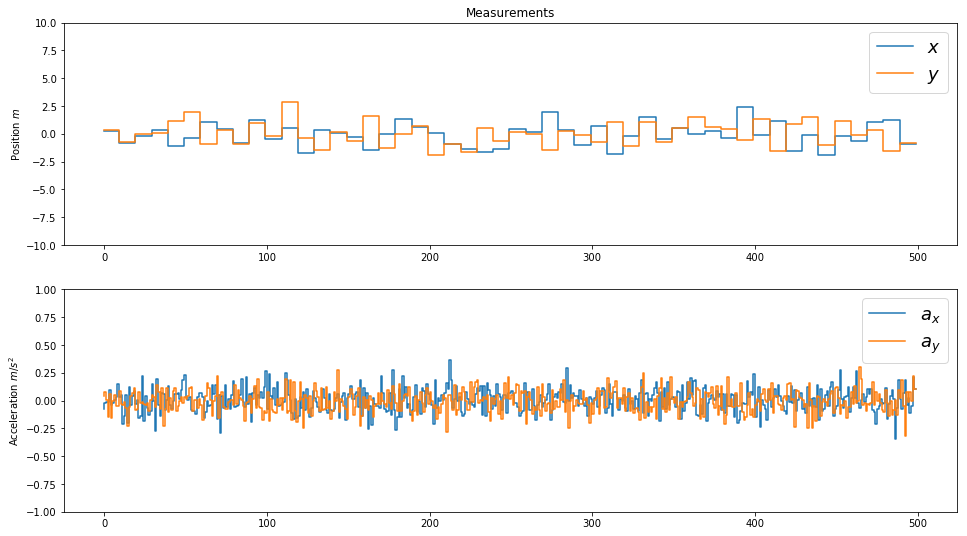

```python
plot_m()
```

## Kalman Filter

[figure not shown]

```python
for filterstep in range(m):

    # Time Update (Prediction)
    # ========================
    # Project the state ahead
    x = A*x

    # Project the error covariance ahead
    P = A*P*A.T + Q


    # Measurement Update (Correction)
    # ===============================
    # if there is a GPS Measurement
    if GPS[filterstep]:
        # Compute the Kalman Gain
        S = H*P*H.T + R
        K = (P*H.T) * np.linalg.pinv(S)


        # Update the estimate via z
        Z = measurements[:,filterstep].reshape(H.shape[0],1)
        y = Z - (H*x)                            # Innovation or Residual
        x = x + (K*y)

        # Update the error covariance
        P = (I - (K*H))*P



    # Save states for Plotting
    savestates(x, Z, P, K)
```

Thats it.

[figure not shown]

# Let's take a look at the filter performance

### Uncertainty $P$

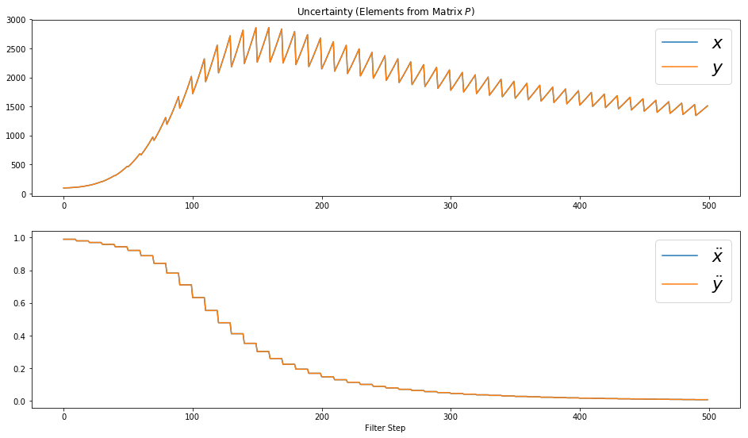

```python
plot_P()
```

### Covariance Matrix

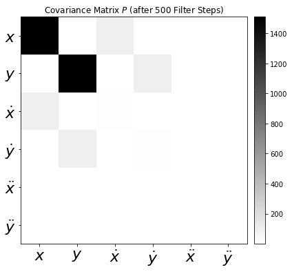

```python
plot_P2()
```

### Kalman Gains

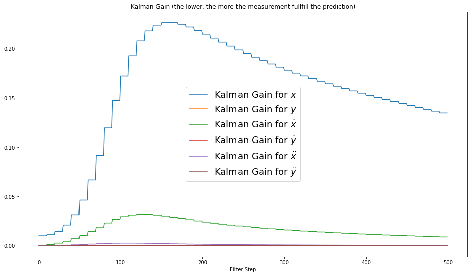

```python
plot_K()
```

## State Vector

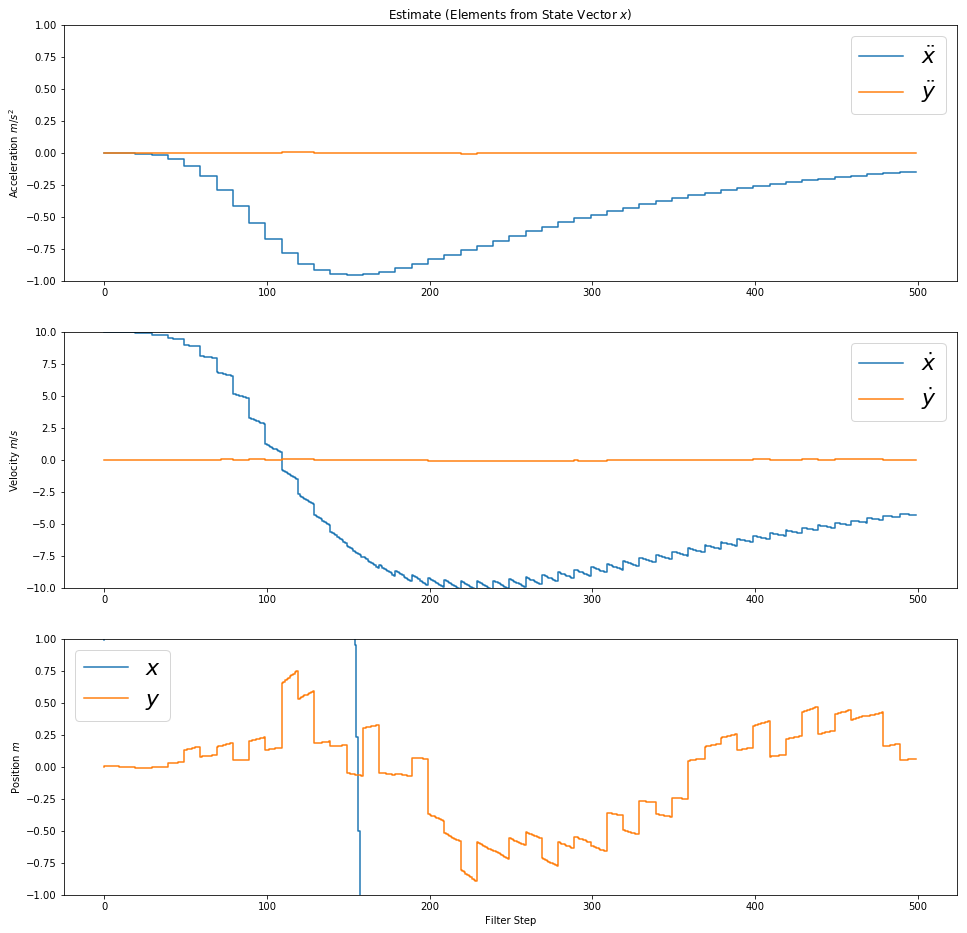

```python
plot_x()
```

## Position x/y

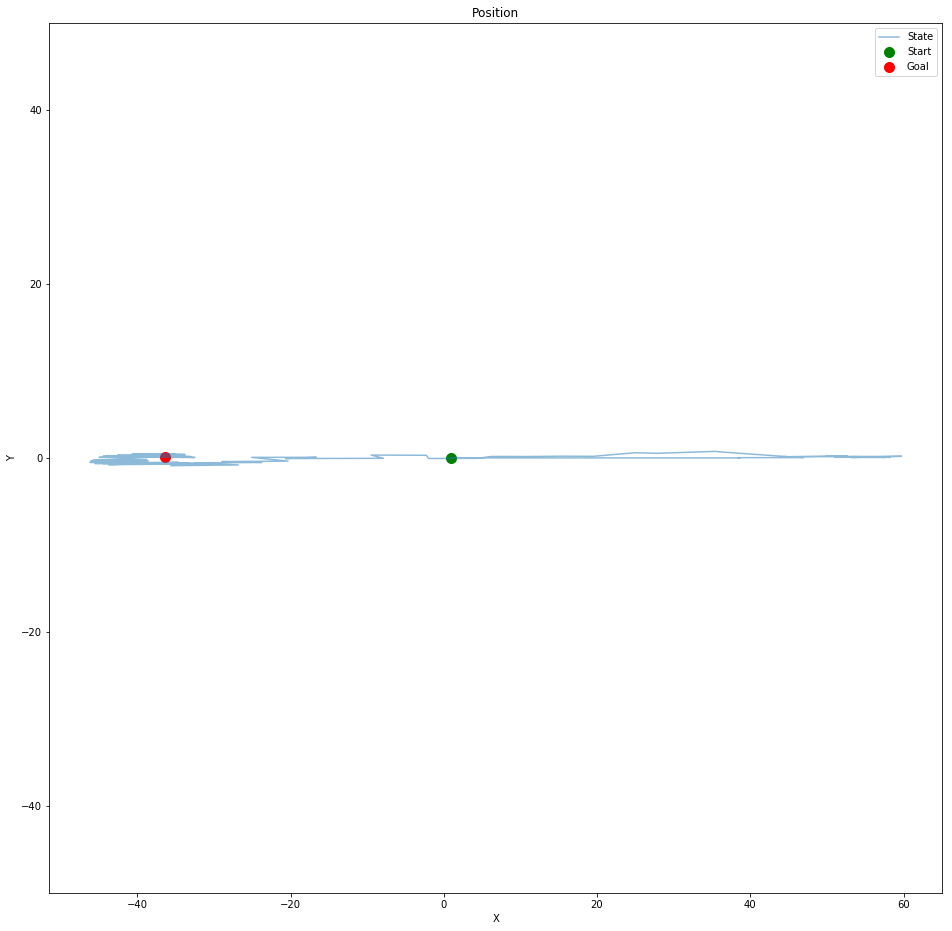

```python
plot_xy()
```

# Conclusion

[figure not shown]